# Preprocessing

- importing map
- whiten available areas
- blacken parts with obstacles and outside areas
- plot the occupancy grid map

[figure not shown]

```python
import skimage.io as skio
import cv2
import numpy as np
from google.colab.patches import cv2_imshow

# Loading the occupancy grid map from an online image URL
url = "https://uploads-ssl.webflow.com/5d5ab0de3f2789196e87264e/5f9999ea1057522149823f0a_de_dust2_radar_Pano0Pat1Buy1Spec0.png"
image = skio.imread(url, as_gray=True)

# Convert the image to binary occupancy grid
threshold = 0.9  # Threshold
grid_map = np.where(image > threshold, 1, 0).astype(np.uint8)

# Reverse the color of the occupancy grid map
reversed_map = cv2.bitwise_not(grid_map* 255) * 255

# Load the occupancy grid map as an OpenCV object
img = cv2.cvtColor(reversed_map* 255, cv2.COLOR_GRAY2BGR)

# Display the occupancy grid map
cv2_imshow(img)
```

[figure not shown]

```python
# Create a copy of the image array
result = np.copy(img)

# Define the fill color (black)
fill_color = 0

# Define the seed points for flood fill
height, width = img.shape[:2]
seed_points = [(0, y) for y in range(height)] + \
              [(width-1, y) for y in range(height)] + \
              [(x, 0) for x in range(width)] + \
              [(x, height-1) for x in range(width)]

# Blacken the outside area
for seed_point in seed_points:
  cv2.floodFill(result, None, seed_point, fill_color)

# Display the resulting image
cv2_imshow(result)
```

[figure not shown]

```python
from skimage.measure import label, regionprops

# Turn unknown space into the color grey
def turn_white_areas_to_grey(image_array):
  # Convert image array to binary format
  threshold = 0.5  # Threshold for grey color
  binary_image = np.where(image_array > threshold, 1, 0)

  # Perform connected component analysis
  labeled_image, num_labels = label(binary_image, connectivity=2, return_num=True)

  # Find the label of the largest region
  largest_region_label = 0
  if num_labels > 0:
    regions = regionprops(labeled_image)
    largest_region_label = max(regions, key=lambda x: x.area).label

  # Modify white pixels in non-largest regions to grey
  gray_value = 90  # Adjust this grey value as desired
  modified_image = np.where((labeled_image != largest_region_label) & (binary_image == 1), gray_value, image_array)

  return modified_image

# Display the resulting image
img = turn_white_areas_to_grey(result)
img = cv2.cvtColor(img, cv2.COLOR_BGR2GRAY)
cv2_imshow(img) # Counter-Strike: Global Offensive -----> Dust 2
```

# BrushFire

- starts from obsticles
- fills the empty space

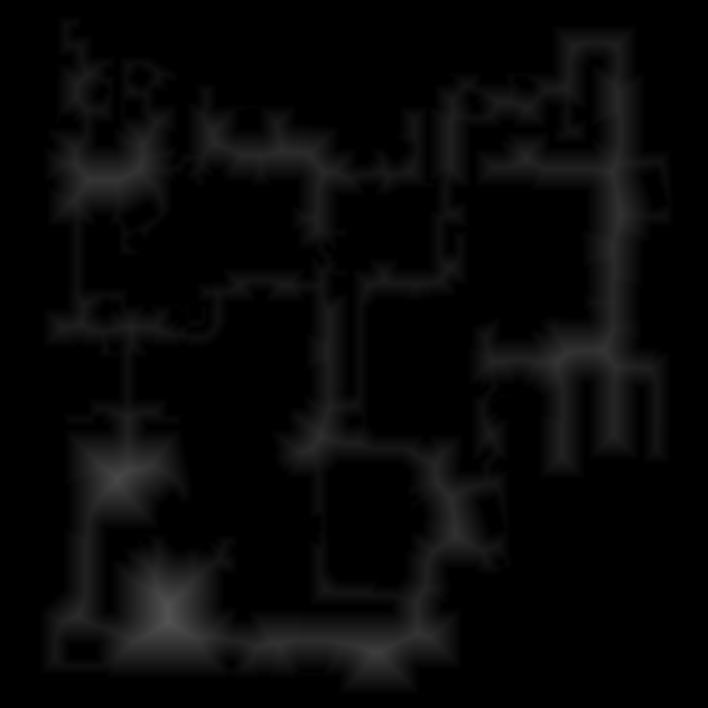

```python
# Create a mask to exclude gray areas
mask = np.where(img == 90, 0, 1).astype(np.uint8)

# Define the kernel for brushfire
kernel = cv2.getStructuringElement(cv2.MORPH_CROSS, (3, 3))

# Perform brushfire on the white areas of the OGM
brushfire = cv2.distanceTransform(mask * (img), cv2.DIST_L2, cv2.DIST_MASK_PRECISE)
brushfire = cv2.dilate(brushfire, kernel)
brushfire = np.uint8(brushfire)

# Display the brushfire field
cv2_imshow(brushfire)
```

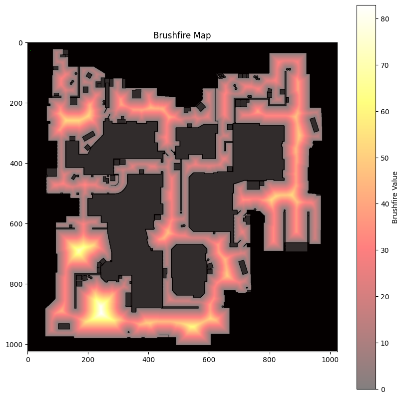

```python
# Better visualization
import numpy as np
import matplotlib.pyplot as plt
from scipy.spatial import cKDTree

ogm = img
resolution = 0.1  # Adjust this value based on your desired resolution
robot_radius = 0.5  # Adjust this value based on your robot size
x, y = np.where(ogm == 255)  # Sample only from free areas

valid_indices = np.random.choice(len(x), size=500, replace=False)  # Adjust the sample size as needed
sampled_points = np.column_stack((y[valid_indices] * resolution, x[valid_indices] * resolution))
kdtree = cKDTree(sampled_points)

# No obstacles
def is_collision_free(point1, point2):
  num_steps = int(np.linalg.norm(point2 - point1) / resolution)
  path_x = np.linspace(point1[0], point2[0], num_steps)
  path_y = np.linspace(point1[1], point2[1], num_steps)
  path_indices = np.column_stack((path_y / resolution, path_x / resolution)).astype(int)
  return np.all(ogm[path_indices[:, 1], path_indices[:, 0]] == 1)

# Brushfire
fire = []
for point in sampled_points:
  distances, indices = kdtree.query(point, k=10)  # Adjust the number of nearest neighbors as needed
  for neighbor_index in indices:
    neighbor = sampled_points[neighbor_index]
    if np.linalg.norm(neighbor - point) <= robot_radius and is_collision_free(point, neighbor):
      fire.append((point, neighbor))

# Display the resulting image
plt.figure(figsize=(10, 10))
plt.imshow(ogm, cmap='gray')
plt.imshow(brushfire, alpha=0.5, cmap='hot', vmin=np.min(brushfire), vmax=np.max(brushfire))
for edge in fire:
  plt.plot([edge[0][0], edge[1][0]], [edge[0][1], edge[1][1]], 'g-', linewidth=0.5)
plt.title('Brushfire Map')
plt.colorbar(label='Brushfire Value')
plt.show()
```

# Uniform PRM

- uniform graph applied on the map
- blue dots are the nodes of the graph
- red dots are the staring and ending points(not necessarily in the graph)
- green lines are the bidirectional connections

```python
import random
import numpy as np
from scipy.spatial import distance
import math

# Function to check if a point is valid (not in obstacle or too close to walls)
def is_valid_point(point, occupancy_map, brushfire_map):
  x, y = point
  obstacle_distance = 6 # This controls the accepted distanse from the obstacles
  if occupancy_map[x, y] == 255 and brushfire_map[x, y] >= obstacle_distance:
    return True
  else:
    return False

occupancy_map = img
brushfire_map = brushfire

# All valid points
valid_points = []
for x in range(0,1023):
  for y in range(0,1023):
    point = (x,y)
    if is_valid_point(point, occupancy_map, brushfire_map):
      valid_points.append(point)
```

```python
# Random goal and start nodes
start_node = random.choice(valid_points)
goal_node = random.choice(valid_points)
```

```python
# Generate PRM with uniform sampling
def generate_prm(occupancy_map, brushfire_map, start_node, goal_node):
  prm_graph = {}
  space_berween_nodes = 6 # Adjust this for more sparce nodes

  # Incorporate start and goal node in the graph
  prm_graph[start_node] = []
  prm_graph[goal_node] = []

  for i in range(0,1024,space_berween_nodes):
    for j in range(0,1024,space_berween_nodes):
      x = i
      y = j
      point = (x, y)
      if is_valid_point(point, occupancy_map, brushfire_map) and point != start_node and point != goal_node:
          prm_graph[point] = []

  for point1 in prm_graph.keys():
    for point2 in prm_graph.keys():
      if math.dist(point1,point2) <= math.sqrt(2*space_berween_nodes**2) and math.dist(point1,point2)!=0:
        prm_graph[point1].append(point2)

  return prm_graph

# Function to plot the PRM graph on the occupancy grid map
def plot_prm_graph(occupancy_map, prm_graph, start_node, goal_node):
  occupancy_map_rgb = cv2.cvtColor(occupancy_map, cv2.COLOR_GRAY2RGB)

  for point, neighbors in prm_graph.items():
    for neighbor in neighbors:
      cv2.line(occupancy_map_rgb, (point[1], point[0]), (neighbor[1], neighbor[0]), (0, 255, 0),1)
  for point, neighbors in prm_graph.items():
    cv2.circle(occupancy_map_rgb, (point[1], point[0]), 0, (255, 0, 0),3)

  cv2.circle(occupancy_map_rgb, (goal_node[1], goal_node[0]), 2, (0, 0, 255), 2)
  cv2.circle(occupancy_map_rgb, (start_node[1], start_node[0]), 2, (0, 0, 255), 2)

  cv2_imshow(occupancy_map_rgb)
```

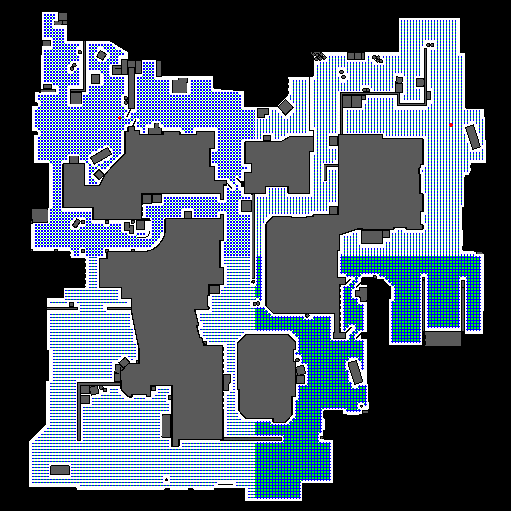

```python
# Make the uniform PRM graph
prm_graph = generate_prm(occupancy_map, brushfire_map, start_node, goal_node)

# Plot the PRM graph on the occupancy grid map
plot_prm_graph(occupancy_map, prm_graph, start_node, goal_node)
```

# Random PRM

- The points are dispersed randomly on the map
- Everything else is the same as above

```python
# Generate PRM with uniform sampling
def generate_rprm(occupancy_map, brushfire_map, start_node, goal_node):
  rprm_graph = {}
  tried_point = 16000 # Adjust this for more/less nodes in the graph
  connection_distanse = 6 # The distance to connect 2 node (its calculated like the uniform prm for comperable results)

  # Incorporate start and goal node in the graph
  rprm_graph[start_node] = []
  rprm_graph[goal_node] = []

  for i in range(tried_point):
    point = random.choice(valid_points)
    if point not in rprm_graph.keys() and point != start_node and point != goal_node:
      rprm_graph[point] = []

  for point1 in rprm_graph.keys():
    for point2 in rprm_graph.keys():
      if math.dist(point1,point2) <= math.sqrt(2*connection_distanse**2) and math.dist(point1,point2)!=0:
        rprm_graph[point1].append(point2)
        rprm_graph[point2].append(point1)

  return rprm_graph
```

```python
## This code can produce a random PRM with a specific number of nodes
# def generate_rprm(valid_point):
#     rprm_graph = {}
#     number_of_nodes = 15000 # Adjust this for more/less nodes in the graph

#     while len(rprm_graph) < number_of_nodes:
#       point = random.choice(valid_points)
#       if point not in rprm_graph.keys():
#         rprm_graph[point] = []


#     for point1 in rprm_graph.keys():
#         for point2 in rprm_graph.keys():
#           if math.dist(point1,point2) <= math.sqrt(72) and math.dist(point1,point2)!=0:
#               rprm_graph[point1].append(point2)
#               rprm_graph[point2].append(point1)

#     return rprm_graph
```

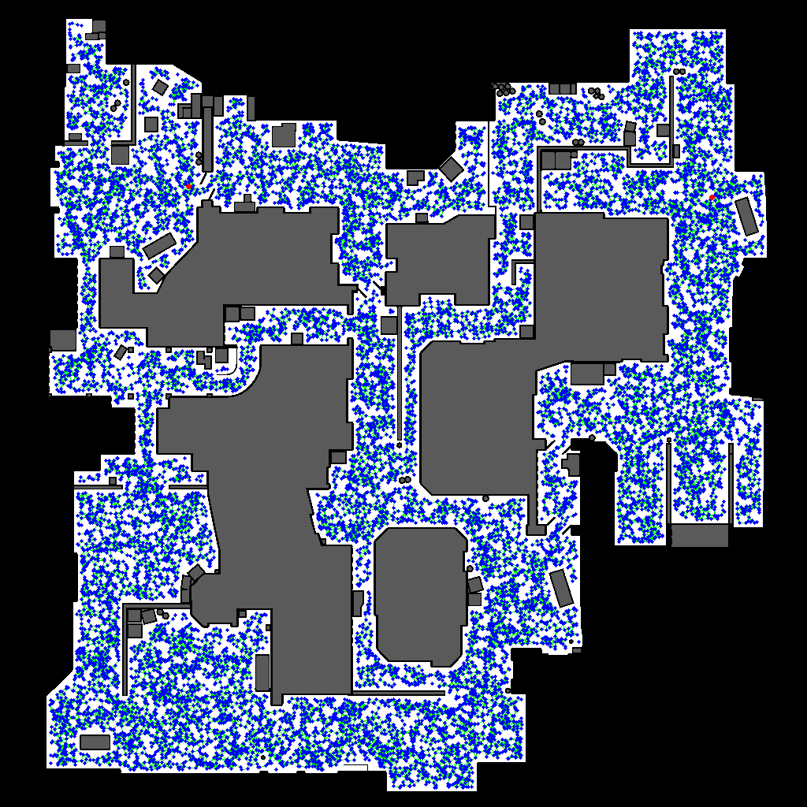

```python
# Calculating the random PRM
rprm_graph = generate_rprm(occupancy_map, brushfire_map, start_node, goal_node)

# Plot the random PRM graph on the occupancy grid map
plot_prm_graph(occupancy_map, rprm_graph, start_node, goal_node)
```

```python
# Random PRM selected nodes
len(rprm_graph)
```

```
15699
```

# Dijkstra & A*

- Applie `dijkstra` and `a_star` on both PRMs
- The path is visible in the plot (blue dots)
- The expansions (searches) are visible in the plot (red lines)

```python
# Path to goal
def find_path(previous):
    path = []
    current_node = goal_node

    while current_node != start_node:
      try:
        path.append(current_node)
        current_node = previous[current_node]
      except KeyError:
        break

    path.reverse()
    return path
```

```python
# Print the best path and visualize the PRM graph
def print_best_graph_path(occupancy_map, prm_graph, distances, previous, path, start_node, goal_node):

  # In case random graph nodes are disconnected
  if distances[goal_node] == float('inf'):
    print("No path found")
    print("Starting nobe:", start_node)
    print("Goal node:", goal_node)
    occupancy_map_rgb = cv2.cvtColor(occupancy_map, cv2.COLOR_GRAY2RGB)
    cv2.circle(occupancy_map_rgb, (start_node[1], start_node[0]), 2, (0, 255, 0), 2)
    cv2.circle(occupancy_map_rgb, (goal_node[1], goal_node[0]), 2, (0, 255, 0), 2)

    # Drawing searched areas
    for point, neighbors in previous.items():
      cv2.line(occupancy_map_rgb, (point[1], point[0]), (neighbors[1], neighbors[0]), (0, 0, 255), 1)

      # Uncomment next line to plot every step (take a long lime)
      # cv2_imshow(occupancy_map_rgb)

    for point in path:
      cv2.circle(occupancy_map_rgb, (point[1], point[0]), 1, (255, 0, 0), 2)

    # Redrawning goal and start so they appear on the top
    cv2.circle(occupancy_map_rgb, (goal_node[1], goal_node[0]), 2, (0, 255, 0), 2)
    cv2.circle(occupancy_map_rgb, (start_node[1], start_node[0]), 2, (0, 255, 0), 2)

    cv2_imshow(occupancy_map_rgb)
    return

  occupancy_map_rgb = cv2.cvtColor(occupancy_map, cv2.COLOR_GRAY2RGB)
  cv2.circle(occupancy_map_rgb, (start_node[1], start_node[0]), 2, (0, 255, 0), 2)
  cv2.circle(occupancy_map_rgb, (goal_node[1], goal_node[0]), 2, (0, 255, 0), 2)

  # Drawing searched areas
  for point, neighbors in previous.items():
    cv2.line(occupancy_map_rgb, (point[1], point[0]), (neighbors[1], neighbors[0]), (0, 0, 255), 1)

    # Uncomment next line to plot every step (take a long lime)
    # cv2_imshow(occupancy_map_rgb)

  for point in path:
    cv2.circle(occupancy_map_rgb, (point[1], point[0]), 1, (255, 0, 0), 2)

  # Redrawning goal and start so they appear on the top
  cv2.circle(occupancy_map_rgb, (goal_node[1], goal_node[0]), 2, (0, 255, 0), 2)
  cv2.circle(occupancy_map_rgb, (start_node[1], start_node[0]), 2, (0, 255, 0), 2)
  cv2_imshow(occupancy_map_rgb)
```

```python
import random
import numpy as np
import cv2
import heapq
import math
from collections import OrderedDict

# Dijkstra's algorithm
def dijkstra(prm_graph, start_node, goal_node):
  distances = {node: float('inf') for node in prm_graph.keys()}
  distances[start_node] = 0
  previous = {}
  priority_queue = [(0, start_node)]
  heapq.heapify(priority_queue)

  while priority_queue:
    current_distance, current_node = heapq.heappop(priority_queue)

    if goal_node == current_node:
      break

    for neighbor in prm_graph[current_node]:
      edge_weight = math.dist(current_node, neighbor)

      distance = current_distance + edge_weight

      # Expanding
      if distance < distances[neighbor]:
        distances[neighbor] = distance
        previous[neighbor] = current_node
        heapq.heappush(priority_queue, (distance, neighbor))

  path = find_path(previous)
  return distances, previous, path
```

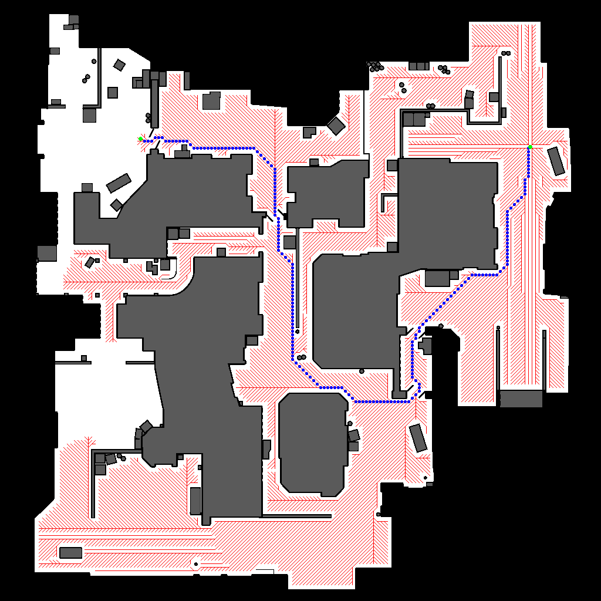

```python
# Dijkstra search on Uniform PRM
distances_dijkstra, previous_dijkstra, path_dijkstra = dijkstra(prm_graph, start_node, goal_node)

# Prin best path
print_best_graph_path(occupancy_map, prm_graph, distances_dijkstra, previous_dijkstra, path_dijkstra, start_node, goal_node)
```

[figure not shown]

```python
# Dijkstra search on Random PRM
distances_dijkstra_r, previous_dijkstra_r, path_dijkstra_r = dijkstra(rprm_graph, start_node, goal_node)

# Prin best path
print_best_graph_path(occupancy_map, rprm_graph, distances_dijkstra_r, previous_dijkstra_r, path_dijkstra_r, start_node, goal_node)
```

```python
import heapq
import math

# A* algorithm
def a_star(prm_graph, start_node, goal_node):
  distances = {node: [float('inf'), float('inf')] for node in prm_graph.keys()}
  distances[start_node] = [0, math.dist(start_node, goal_node)]
  previous = {}

  priority_queue = [(distances[start_node][0], start_node)]
  heapq.heapify(priority_queue)

  while priority_queue:
    current_distance, current_node = heapq.heappop(priority_queue)

    if goal_node == current_node:
      break

    if current_distance > distances[current_node][0] + distances[current_node][1]:
      continue

    for neighbor in prm_graph[current_node]:
      edge_weight = math.dist(current_node, neighbor)

      distance = distances[current_node][0] + edge_weight
      heuristic_distance = math.dist(neighbor, goal_node)
      total_distance = distance + heuristic_distance

      # Finding best place to expand
      if total_distance < distances[neighbor][0] + distances[neighbor][1]:
        distances[neighbor] = [distance, heuristic_distance]
        previous[neighbor] = current_node
        heapq.heappush(priority_queue, (total_distance, neighbor))

  path = find_path(previous)
  return distances, previous, path
```

[figure not shown]

```python
# A* search in Uniform PRM
distances_a_star, previous_a_star, path_a_star = a_star(prm_graph, start_node, goal_node)

# Prin best path
print_best_graph_path(occupancy_map, prm_graph, distances_a_star, previous_a_star, path_a_star, start_node, goal_node)
```

[figure not shown]

```python
# A* search in Rnadom PRM
distances_a_star_r, previous_a_star_r, path_a_star_r = a_star(rprm_graph, start_node, goal_node)

# Prin best path
print_best_graph_path(occupancy_map, rprm_graph, distances_a_star_r, previous_a_star_r, path_a_star_r, start_node, goal_node)
```

# Rapidly-expaning Random Tree (RRT)

- the RRT algorithm does not use the graph
- instead makes a new (random) path inside the empty space

```python
# Print the best path and visualize the PRM graph
def print_best_tree_path(occupancy_map, rrt, path, start_node, goal_node):

  occupancy_map_rgb = cv2.cvtColor(occupancy_map, cv2.COLOR_GRAY2RGB)
  cv2.circle(occupancy_map_rgb, (start_node[1], start_node[0]), 2, (0, 255, 0), 2)
  cv2.circle(occupancy_map_rgb, (goal_node[1], goal_node[0]), 2, (0, 255, 0), 2)
  for point, neighbors in rrt.items():
    if rrt[start_node][0]==0:
      for neighbor in neighbors[1:]:
        cv2.line(occupancy_map_rgb, (point[1], point[0]), (neighbor[1], neighbor[0]), (0, 0, 255), 1)
    else:
      for neighbor in neighbors:
        cv2.line(occupancy_map_rgb, (point[1], point[0]), (neighbor[1], neighbor[0]), (0, 0, 255), 1)

        # Uncomment next line to plot every step (takes a long lime)
        # cv2_imshow(occupancy_map_rgb)

  for point in path:
    cv2.circle(occupancy_map_rgb, (point[1], point[0]), 1, (255, 0, 0), 2)

  cv2.circle(occupancy_map_rgb, (goal_node[1], goal_node[0]), 2, (0, 255, 0), 2)
  cv2.circle(occupancy_map_rgb, (start_node[1], start_node[0]), 2, (0, 255, 0), 2)

  cv2_imshow(occupancy_map_rgb)
```

```python
# Function to find the tree path that lead to the goal
def trace_backward(tree, start_node, goal_node):
  path = [goal_node]
  current_node = goal_node
  count = 0
  while current_node != start_node:
    for parent_node, child_nodes in tree.items():
      for node in child_nodes:
        if node == current_node:
          current_node = parent_node
          path.append(current_node)
    if count > len(tree):
      break
    count += 1
  return path
```

```python
# Generate RRT with uniform sampling
def generate_RRT(valid_points, start_node, goal_node, occupancy_map, brushfire_map):
  rrt = {}
  rrt[start_node] = []
  nearest_node = ()

  while math.dist(list(rrt.keys())[-1], goal_node) > 5:
    rand_point = random.choice(valid_points)
    min_dist = float('inf')

    # Random point generation and nearest node
    if rand_point not in rrt.keys():
      for i in rrt.keys():
        dist = math.dist(i ,rand_point)
        if min_dist > dist:
          min_dist = dist
          nearest_node = i

      # Calculate the coordinates of the new point
      new_node = (round(nearest_node[0] + 5/min_dist * (rand_point[0] - nearest_node[0])),
                  round( nearest_node[1] + 5/min_dist * (rand_point[1] - nearest_node[1])))

      # Check if valid them append it to the tree
      if is_valid_point(new_node, occupancy_map, brushfire_map) and new_node not in rrt.keys():
        rrt[new_node] = []
        rrt[nearest_node].append(new_node)

  # Connect to the goal node if its close enough
  rrt[goal_node] = []
  rrt[new_node] = [goal_node]
  return rrt
```

[figure not shown]

```python
# Calculate the tree
rrt = generate_RRT(valid_points, start_node, goal_node, occupancy_map, brushfire_map)

# Tree path to goal
path_rrt = trace_backward(rrt, start_node, goal_node)

# Print random RRT
print_best_tree_path(occupancy_map, rrt, path_rrt, start_node, goal_node)
```

# Rapidly-expaning Random Tree star(RRT*)

- The way of expansion is a little different resulting on combed looking tree
- This algorith has the choise of running for double the duration for an even more "combed" tree

```python
# Generate RRT with uniform sampling
def RRT_star(valid_points, start_node, goal_node, occupancy_map, brushfire_map):
  rrt = {}
  rrt[start_node] = [0]
  nearest_node = ()
  count1 = 0 # Count how long it took until it reached the goal

  # Repeat until u find the goal
  while math.dist(list(rrt.keys())[-1], goal_node) > 5:
    count1 += 1
    rand_point = random.choice(valid_points)
    min_dist = float('inf')
    min_dist2 = float('inf')
    if rand_point not in rrt.keys():
      for i in rrt.keys():
        dist = math.dist(i ,rand_point)
        if min_dist > dist:
          min_dist = dist
          nearest_node = i

      # Calculate the coordinates of the new point
      new_node = (round(nearest_node[0] + 5/min_dist * (rand_point[0] - nearest_node[0])),
                  round( nearest_node[1] + 5/min_dist * (rand_point[1] - nearest_node[1])))

      # Choose node to connect based on distance from the start
      if is_valid_point(new_node, occupancy_map, brushfire_map) and new_node not in rrt.keys():
        for key,values in rrt.items():
          if math.dist(new_node, key) < 10:
            dist = rrt[key][0] + math.dist(new_node, key) # Distance closer to start
            if min_dist2 > dist:
                min_dist2 = dist
                nearest_node = key
        rrt[new_node] = [min_dist2]
        rrt[nearest_node].append(new_node)

        # Connect nearby node to the new one and remove them from the previously connected
        for key, values in rrt.items():
          if math.dist(new_node, key) < 10 and new_node != key:
            if math.dist(new_node, key) + rrt[new_node][0] < rrt[key][0]:
              for i in values:
                if i is float:
                  rrt[key].remove(i)
                  rrt[key] = [math.dist(new_node, key) + min_dist2] + rrt[key]
              rrt[new_node].append(key)
              for k,v in rrt.items():
                if len(v)>1 and k!=new_node:
                  for i in v:
                    if i == key:
                      rrt[k].remove(i)

  goal_di = math.dist(list(rrt.keys())[-1], goal_node) + rrt[list(rrt.keys())[-1]][0]
  rrt[goal_node] = [goal_di]
  rrt[new_node].append(goal_node)

  # Running for double the iterations
  for i in range(count1):
    rand_point = random.choice(valid_points)
    min_dist = float('inf')
    min_dist2 = float('inf')
    if rand_point not in rrt.keys():
      for i in rrt.keys():
        dist = math.dist(i ,rand_point)
        if min_dist > dist:
          min_dist = dist
          nearest_node = i

      # Calculate the coordinates of the new point
      new_node = (round(nearest_node[0] + 5/min_dist * (rand_point[0] - nearest_node[0])),
                  round( nearest_node[1] + 5/min_dist * (rand_point[1] - nearest_node[1])))

      # Choose node to connect based on distance from the start
      if is_valid_point(new_node, occupancy_map, brushfire_map) and new_node not in rrt.keys():
        for key,values in rrt.items():
          if math.dist(new_node, key) < 10:
            dist = rrt[key][0] + math.dist(new_node, key) # Distance closer to start
            if min_dist2 > dist:
              min_dist2 = dist
              nearest_node = key
        rrt[new_node] = [min_dist2]
        rrt[nearest_node].append(new_node)

        # Connect nearby node to the new one and remove them from the previously connected
        for key, values in rrt.items():
          if math.dist(new_node, key) < 10 and new_node != key and key != goal_node:
            if math.dist(new_node, key) + rrt[new_node][0] < rrt[key][0]:
              for i in values:
                if i is float:
                  rrt[key].remove(i)
                  rrt[key] = [math.dist(new_node, key) + min_dist2] + rrt[key]
              rrt[new_node].append(key)
              for k,v in rrt.items():
                if len(v)>1 and k!=new_node:
                  for i in v:
                    if i == key:
                      rrt[k].remove(i)
  return rrt

# Calculate RRT*
rrt_star = RRT_star(valid_points, start_node, goal_node, occupancy_map, brushfire_map)
```

[figure not shown]

```python
# Tree path to goal
path_rrt_star = trace_backward(rrt_star, start_node, goal_node)

# Print RRT*
print_best_tree_path(occupancy_map, rrt_star, path_rrt_star, start_node, goal_node)
```

# Path smoothing

- Makes the path smoother to allow for model restrictions
- Attenion is needed so the new path does not overlap with objecles

```python
def path_smoothing(points, occupancy_map, brushfire_map, learning_rate=0.1, iterations=100):
  path = np.array(points, dtype=float)

  for _ in range(iterations):
    gradients = np.zeros_like(path)

    for i in range(1, len(path) - 1):
      prev_point = path[i-1]
      next_point = path[i+1]

      # Calculate the gradient as the difference between adjacent points
      gradients[i] = (prev_point - path[i]) + (next_point - path[i])

    # Update the path using gradient descent
    path += learning_rate * gradients

    # Check if smoothed path collided with obstacle
    for i in range(len(path)):
      point = path[i]
      rounded_point = np.round(point).astype(int)
      rounded_point = rounded_point.tolist()

      # Replace point that have collided with obstacle and the two connected to it points
      if is_valid_point(rounded_point, occupancy_map, brushfire_map) == False:
        path[i] = path[i] - learning_rate * gradients[i]
        path[i-1] = path[i-1] - learning_rate * gradients[i-1]
        path[i+1] = path[i+1] - learning_rate * gradients[i+1]

  path = np.round(path).astype(int)
  path = path.tolist()
  return path
```

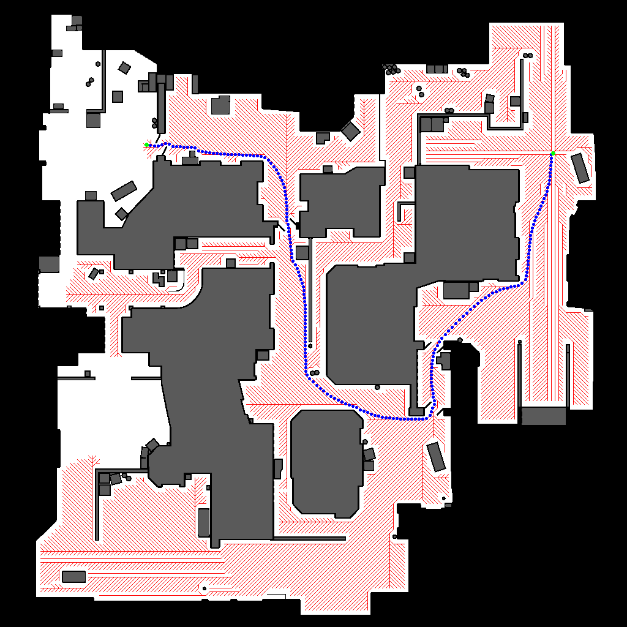

```python
# Smoothed Dijkstra path on uniform PRM
smoothed_path_Dijkstra_prm = path_smoothing(path_dijkstra, occupancy_map, brushfire_map)
print_best_graph_path(occupancy_map, prm_graph, distances_dijkstra, previous_dijkstra, smoothed_path_Dijkstra_prm, start_node, goal_node)
```

[figure not shown]

```python
# Smoothed Dijkstra path on Random PRM
smoothed_path_Dijkstra_rprm = path_smoothing(path_dijkstra_r, occupancy_map, brushfire_map)
print_best_graph_path(occupancy_map, rprm_graph, distances_dijkstra_r, previous_dijkstra_r, smoothed_path_Dijkstra_rprm, start_node, goal_node)
```

[figure not shown]

```python
# Smoothed A* path on uniform PRM
smoothed_path_a_star_prm = path_smoothing(path_a_star, occupancy_map, brushfire_map)
print_best_graph_path(occupancy_map, prm_graph, distances_a_star, previous_a_star, smoothed_path_a_star_prm, start_node, goal_node)
```

[figure not shown]

```python
# Smoothed A* path on Random PRM
smoothed_path_a_star_rprm = path_smoothing(path_a_star_r, occupancy_map, brushfire_map)
print_best_graph_path(occupancy_map, rprm_graph, distances_a_star_r, previous_a_star_r, smoothed_path_a_star_rprm, start_node, goal_node)
```

[figure not shown]

```python
# Smoothed random RRT path
smoothed_path_rrt = path_smoothing(path_rrt, occupancy_map, brushfire_map)
print_best_tree_path(occupancy_map, rrt, smoothed_path_rrt, start_node, goal_node)
```

[figure not shown]

```python
# Smoothed RRT* path
smoothed_path_rrt_star = path_smoothing(path_rrt_star, occupancy_map, brushfire_map)
print_best_tree_path(occupancy_map, rrt_star, smoothed_path_rrt_star, start_node, goal_node)
```